# Estimating the number of people without a garden

```r
library(tidyverse)
library(janitor)    # for data cleaning
library(readxl)     # for readig excel files
library(visdat)     # for a quick look at data quality
```

## Processing the data

### Gardens data

Dataset downloaded from [ONS](https://www.ons.gov.uk/economy/environmentalaccounts/datasets/accesstogardensandpublicgreenspaceingreatbritain) on 5th June 2021. Both gardens space and public parks datasets are the April 2020 versions.

```r
# a convenience function for renaming columns
# I am sure there is a better way to do this!
replace_in_column_name <- function(df, pattern, replacement){
  df %>%
    rename_with(.fn = ~ str_replace(.x, pattern, replacement))
}

# read in and clean data
gardens <- read_xlsx(
  "data/osprivateoutdoorspacereferencetables_edited_for_import.xlsx",
  sheet = "MSOA gardens",
  skip = 1) %>%

  # make variables names more conistent
  janitor::clean_names() %>%

  # focus on variables of interest
  select(country_code:msoa_name,
         ends_with("count") |
         starts_with("total")) %>%

  # simplify variables names (now data by housing type has been removed)
  replace_in_column_name("total_", "") %>%
  replace_in_column_name("private_outdoor_space", "gar") %>%
  replace_in_column_name("address", "ad") %>%
  replace_in_column_name("adress", "ad") %>%
  replace_in_column_name("adresses", "ads") %>%
  replace_in_column_name("percentage", "perc") %>%
  replace_in_column_name("_m2", "") %>%
  replace_in_column_name("average", "ave")

# display data for quick visual checks
gardens
```

| country_code | country_name | region_code | region_name | lad_code | lad_name | msoa_code | msoa_name | houses_ad_count | houses_ad_with_gar_count | flats_ad_count | flats_ad_with_gar_count | flats_gar_count | ad_count | ad_with_gar_count | gar_total_area | perc_of_ades_with_gar | ave_size_of_gar |
| --- | --- | --- | --- | --- | --- | --- | --- | --- | --- | --- | --- | --- | --- | --- | --- | --- | --- |
| E92000001 | England | E12000007 | London | E09000001 | City of London | E02000001 | City of London 001 | 74 | 20 | 7633 | 534 | 13.4 | 7707 | 554 | 3674.5 | 0.072 | 110.0 |
| E92000001 | England | E12000007 | London | E09000002 | Barking and Dagenham | E02000002 | Barking and Dagenham 001 | 1728 | 1698 | 1237 | 595 | 165.4 | 2965 | 2293 | 1236691.1 | 0.773 | 663.7 |
| E92000001 | England | E12000007 | London | E09000002 | Barking and Dagenham | E02000003 | Barking and Dagenham 002 | 2656 | 2634 | 1415 | 866 | 323.8 | 4071 | 3500 | 502488.6 | 0.860 | 169.9 |
| E92000001 | England | E12000007 | London | E09000002 | Barking and Dagenham | E02000004 | Barking and Dagenham 003 | 2051 | 2037 | 339 | 174 | 98.1 | 2390 | 2211 | 406017.6 | 0.925 | 190.2 |
| E92000001 | England | E12000007 | London | E09000002 | Barking and Dagenham | E02000005 | Barking and Dagenham 004 | 3115 | 3089 | 545 | 385 | 119.2 | 3660 | 3474 | 438159.0 | 0.949 | 136.6 |
| E92000001 | England | E12000007 | London | E09000002 | Barking and Dagenham | E02000007 | Barking and Dagenham 006 | 2099 | 2068 | 1511 | 774 | 196.8 | 3610 | 2842 | 349468.9 | 0.787 | 154.3 |
| E92000001 | England | E12000007 | London | E09000002 | Barking and Dagenham | E02000008 | Barking and Dagenham 007 | 3898 | 3878 | 840 | 662 | 234.9 | 4738 | 4540 | 576069.3 | 0.958 | 140.1 |
| E92000001 | England | E12000007 | London | E09000002 | Barking and Dagenham | E02000009 | Barking and Dagenham 008 | 2825 | 2800 | 1418 | 887 | 125.5 | 4243 | 3687 | 425950.7 | 0.869 | 145.6 |
| E92000001 | England | E12000007 | London | E09000002 | Barking and Dagenham | E02000010 | Barking and Dagenham 009 | 2942 | 2923 | 485 | 237 | 116.8 | 3427 | 3160 | 448967.6 | 0.922 | 147.7 |
| E92000001 | England | E12000007 | London | E09000002 | Barking and Dagenham | E02000011 | Barking and Dagenham 010 | 1781 | 1770 | 694 | 509 | 112.8 | 2475 | 2279 | 324984.3 | 0.921 | 172.6 |

[output cut: 990 more lines]

```r
NA
NA
```

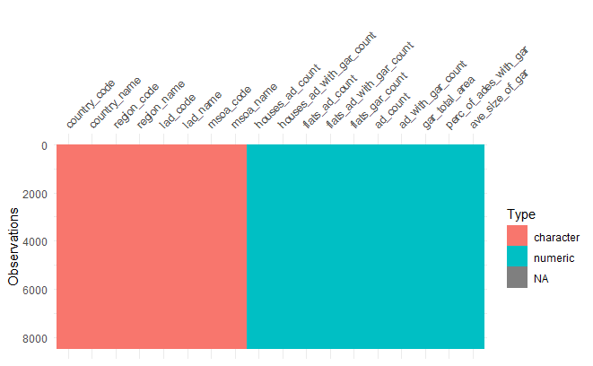

```r
# get a quick visual summary of data types and the amount of missing data
gardens %>%
  visdat::vis_dat()
```

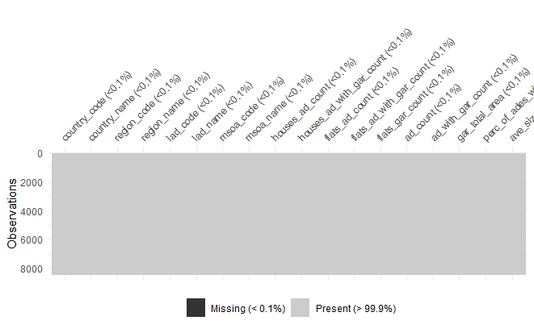

```r
gardens %>%
  visdat::vis_miss()
```

### Indicies of multiple deprivation

ONS released the 2019 IMD data at LSOA scale. MySociety have produced [IMD at various other scales](https://research.mysociety.org/sites/imd2019/about/) including the MSOA scale.

```r
imd_2019 <- read_csv("data/imd2019_msoa_level_data.csv")
imd_2019
```

| MSOAC | MSOAHOCLN | LAD19C | LAD19N | REG | LSOACOUNT | POPMID15 | IMD19 SCORE | MSOARANK | MSOADECILE | MSOAQUINTILE |
| --- | --- | --- | --- | --- | --- | --- | --- | --- | --- | --- |
| E02000001 | City of London | E09000001 | City of London | London | 6 | 6687 | 14.720484 | 4198 | 7 | 4 |
| E02000002 | Marks Gate | E09000002 | Barking and Dagenham | London | 4 | 7379 | 34.767560 | 1060 | 2 | 1 |
| E02000003 | Chadwell Heath East | E09000002 | Barking and Dagenham | London | 6 | 10720 | 25.149726 | 2200 | 4 | 2 |
| E02000004 | Eastbrookend | E09000002 | Barking and Dagenham | London | 4 | 6536 | 23.560044 | 2429 | 4 | 2 |
| E02000005 | Becontree Heath | E09000002 | Barking and Dagenham | London | 5 | 9243 | 30.212965 | 1519 | 3 | 2 |
| E02000007 | Central Park & Frizlands Lane | E09000002 | Barking and Dagenham | London | 5 | 9664 | 36.007463 | 965 | 2 | 1 |
| E02000008 | Becontree East | E09000002 | Barking and Dagenham | London | 7 | 12282 | 34.449585 | 1088 | 2 | 1 |
| E02000009 | Becontree West | E09000002 | Barking and Dagenham | London | 6 | 10504 | 36.336546 | 945 | 2 | 1 |
| E02000010 | Dagenham North | E09000002 | Barking and Dagenham | London | 5 | 9091 | 34.493359 | 1083 | 2 | 1 |
| E02000011 | Dagenham Eastbrook | E09000002 | Barking and Dagenham | London | 4 | 6761 | 25.713969 | 2122 | 4 | 2 |

[output cut: 990 more lines]

### Population data

ONS provide [MSOA level population data](https://www.ons.gov.uk/peoplepopulationandcommunity/populationandmigration/populationestimates/datasets/middlesuperoutputareamidyearpopulationestimates). Here I use the most recent release (mid 2019).

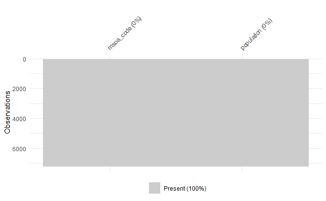

```r
msoa_pops <- read_xlsx(

  "data/SAPE22DT4-mid-2019-msoa-syoa-estimates-unformatted.xlsx",
  sheet = "Mid-2019 Persons",
  skip = 4) %>%

  # process variable names for conistency
  janitor::clean_names() %>%

  # select minimal number of columns
  select(msoa_code, population = all_ages)

msoa_pops %>%
  visdat::vis_miss()
```

### Transforming the data for plotting

Overall average = 2.4 (2020 see [here](https://www.ons.gov.uk/peoplepopulationandcommunity/birthsdeathsandmarriages/families/bulletins/familiesandhouseholds/2020))

2017-18 was the most year I could find on [average occupancy figures broken down by house/flat from MCHLG](https://assets.publishing.service.gov.uk/government/uploads/system/uploads/attachment_data/file/817286/EHS_2017-18_Households_Report.pdf):

- House = 2.5 people
- High-rise flat = 1.9
- Mid-rise flat = 1.8

More details [here](https://www.gov.uk/government/statistics/english-housing-survey-2017-to-2018-households).

**I looked at trying to estimate more accurately, but the figures for the number of dwellings per block are not available.**

- 12,500 blocks of high rise flats
- 77,500 blocks of mid rise flats

```
Warning: Removed 1282 rows containing non-finite values (stat_bin).
```

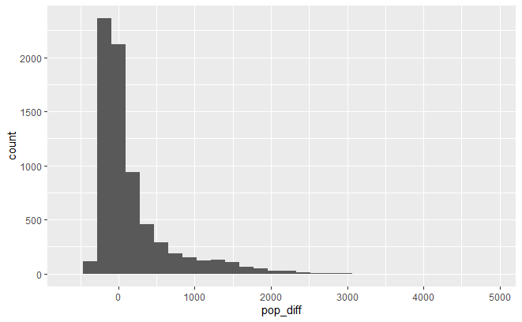

```r
# calculate scaling factors for ave occupancy in an MSOA
# from national data
nat_ave_occ <- 2.4
nat_house_ave_occ <- 2.5
nat_flat_ave_occ <- 1.9

flat_scale <- nat_flat_ave_occ / nat_ave_occ
house_scale <- nat_house_ave_occ / nat_ave_occ


people_wo_gar <- gardens %>%
  left_join(msoa_pops) %>%
  mutate(house_ad_without_gar_count = houses_ad_count - houses_ad_with_gar_count,
         flats_ad_without_gar_count = flats_ad_count - flats_ad_with_gar_count,
         ave_occ = population / ad_count,
         ave_occ_flat = flat_scale * ave_occ,
         ave_occ_house = house_scale * ave_occ,
         pop_calc = (ave_occ_flat * flats_ad_count) + (ave_occ_house * houses_ad_count),
         pop_diff = population - pop_calc)
ggplot(people_wo_gar, aes(pop_diff)) +
  geom_histogram()
```

```r
NA
```

May be more accurate to just use average occupancy rates for each MSOA??

```r
people_wo_gar <- gardens %>%
  left_join(msoa_pops) %>%
  mutate(ad_wo_gar = ad_count * (1 - perc_of_ades_with_gar),
         ave_occ = population / ad_count,
         people_wo_gar = round(ad_wo_gar * ave_occ)) %>%
  select(country_code:msoa_name, people_wo_gar)
people_wo_gar
```

| country_code | country_name | region_code | region_name | lad_code | lad_name | msoa_code | msoa_name | people_wo_gar |
| --- | --- | --- | --- | --- | --- | --- | --- | --- |
| E92000001 | England | E12000007 | London | E09000001 | City of London | E02000001 | City of London 001 | 9021 |
| E92000001 | England | E12000007 | London | E09000002 | Barking and Dagenham | E02000002 | Barking and Dagenham 001 | 1756 |
| E92000001 | England | E12000007 | London | E09000002 | Barking and Dagenham | E02000003 | Barking and Dagenham 002 | 1564 |
| E92000001 | England | E12000007 | London | E09000002 | Barking and Dagenham | E02000004 | Barking and Dagenham 003 | 502 |
| E92000001 | England | E12000007 | London | E09000002 | Barking and Dagenham | E02000005 | Barking and Dagenham 004 | 532 |
| E92000001 | England | E12000007 | London | E09000002 | Barking and Dagenham | E02000007 | Barking and Dagenham 006 | 2140 |
| E92000001 | England | E12000007 | London | E09000002 | Barking and Dagenham | E02000008 | Barking and Dagenham 007 | 532 |
| E92000001 | England | E12000007 | London | E09000002 | Barking and Dagenham | E02000009 | Barking and Dagenham 008 | 1550 |
| E92000001 | England | E12000007 | London | E09000002 | Barking and Dagenham | E02000010 | Barking and Dagenham 009 | 718 |
| E92000001 | England | E12000007 | London | E09000002 | Barking and Dagenham | E02000011 | Barking and Dagenham 010 | 553 |

[output cut: 990 more lines]

```
Warning: Removed 1282 rows containing non-finite values (stat_bin).
```

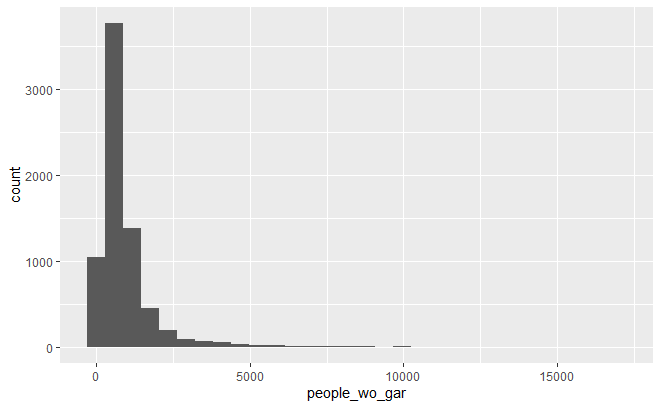

```r
ggplot(people_wo_gar, aes(people_wo_gar)) +
  geom_histogram()
```

https://www.robert-hickman.eu/post/getis-ord-heatmaps-tutorial/

[figure not shown]